# Milestone 5

Robert McKenzie

3/27/2020

My paper is by Ernesto Calvo and Jonathan Rodden, based on unfinished research about the spatial organization of elections[^1]. Their goal was to develop a model that would establish a relationship between a party’s territorial distribution and the number of seats that party would win in a first-past-the-post election. They ended up building two models, one based on theoretical simulated data and one based on real empirical data of UK elections since 1950. They then evaluate both models on the set of UK data. The models, given the territorial distribution of diffrent parties, predicts with a high degree of accuracy the expected biases that will be introduced by voting in many small territorial pools as opposed to all at once. The main result of their model is that majoritarian biases increase as the number of parties contesting an election goes up, that small parties are hurt when their vote is dispersed, and that large parties are hurt when their vote is concentrated. They also drew some specific conclusions about the UK elections: that Labour suffers fewer losses when they do poorly and wins more seats when they do well than their proportion of total votes, that the Conservatives have a consistent seat premium that comes from being large and geographically dispersed, and that the Liberals shifting from a regionally concentrated party to a more dispersed party has hurt their election outcomes substantially. They ran their analyses in a really unique way, mostly outside R using a program called WinBugs, which builds models off of simulated data using a Monte Carlo method. WinBugs is difficult to decipher, but it’s a powerful tool for building rigorous models using bootstrapping. I plan on rebuilding their model using rstanarm, and seeing if the model ends up being substantially different. Repo Location avaiable below.[^2]

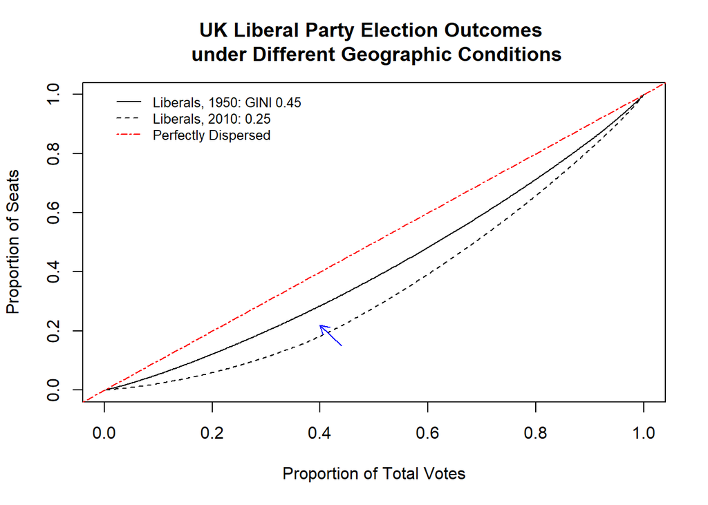

Data and Graph from Harvard Dataverse edition of The Achilles Heel of Plurality Systems: Geography and Representation in Multiparty Democracies[^3]

## Appendix

#### Original Table

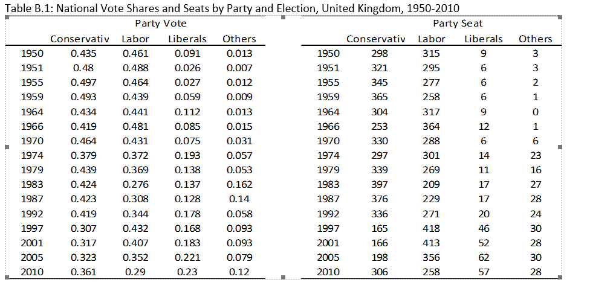

original table

#### My Table(s)

| Year | Conservatives | Labor | Liberals | Others |
| --- | --- | --- | --- | --- |
| 1950 | 0.433 | 0.473 | 0.094 | 0.008 |
| 1951 | 0.479 | 0.495 | 0.026 | 0.003 |
| 1955 | 0.496 | 0.477 | 0.027 | 0.004 |
| 1959 | 0.491 | 0.450 | 0.059 | 0.006 |
| 1964 | 0.431 | 0.455 | 0.114 | 0.008 |
| 1966 | 0.419 | 0.495 | 0.087 | 0.011 |
| 1970 | 0.471 | 0.451 | 0.078 | 0.022 |
| 1974 | 0.401 | 0.398 | 0.201 | 0.034 |
| 1979 | 0.462 | 0.393 | 0.144 | 0.032 |
| 1983 | 0.444 | 0.291 | 0.265 | 0.022 |
| 1987 | 0.439 | 0.323 | 0.238 | 0.021 |
| 1992 | 0.442 | 0.369 | 0.189 | 0.038 |
| 1997 | 0.337 | 0.479 | 0.184 | 0.068 |
| 2001 | 0.346 | 0.453 | 0.201 | 0.064 |
| 2005 | 0.357 | 0.398 | 0.246 | 0.079 |
| 2010 | 0.406 | 0.334 | 0.260 | 0.085 |

| Year | Conservatives | Labor | Liberals | Others |
| --- | --- | --- | --- | --- |
| 1950 | 288 | 316 | 8 | 0 |
| 1951 | 312 | 295 | 6 | 0 |
| 1955 | 334 | 276 | 5 | 0 |
| 1959 | 353 | 257 | 5 | 0 |
| 1964 | 290 | 319 | 9 | 0 |
| 1966 | 242 | 363 | 12 | 0 |
| 1970 | 323 | 286 | 6 | 2 |
| 1974 | 297 | 297 | 13 | 13 |
| 1979 | 339 | 268 | 10 | 5 |
| 1983 | 398 | 208 | 23 | 4 |
| 1987 | 375 | 228 | 24 | 6 |
| 1992 | 336 | 271 | 19 | 8 |
| 1997 | 167 | 417 | 46 | 9 |
| 2001 | 165 | 412 | 52 | 11 |
| 2005 | 197 | 353 | 61 | 15 |
| 2010 | 305 | 258 | 57 | 10 |

## References

Ernesto Calvo, Jonathan Rodden. 2014. “The Achilles Heel of Plurality Systems: Geography and Representation in Multiparty Democracies.” https://onlinelibrary-wiley-com.ezp-prod1.hul.harvard.edu/doi/10.1111/ajps.12167.

———. 2015. “Replication Data for: The Achilles Heel of Plurality Systems: Geography and Representation in Multiparty Democracies.” https://dataverse.harvard.edu/dataset.xhtml?persistentId=doi:10.7910/DVN/27325.

Graham Gudgin, Peter J. Taylor. 1979. *Seats, Votes and the Spatial Organisation of Elections.* London:Pion. https://books.google.ca/books?hl=en&lr=&id=3UVLAQAAQBAJ&oi=fnd&pg=PR41&ots=_N1GGhISVG&sig=fCeSQkXIzKQiFgViJIj-EWsVW9Q&redir_esc=y#v=onepage&q&f=false.

Ronald Johnston. 1979. *Political, Electoral and Spatial Systems.* Oxford:Oxford University Press. https://pdfs.semanticscholar.org/2da8/9052f5886186cf95b7084a64893f4d159d26.pdf.

———. 2002. “Manipulating Maps and Winning Elections: Measuring the Impact of Malapportionment and Gerrymandering.” https://www.sciencedirect.com/science/article/abs/pii/S0962629801000701.

[^1]: Gudgin and Taylor, 1979
[^2]: All analysis for this paper is available [here.](https://github.com/rmckenzie11/Replication_1006)
[^3]: Calvo and Rodden, 2014